# Adjectives

erin

# Math

Literal Listener’s probability distribution over the values $X$ are is prior, conditioned on the utterance being true and renormalized.

$P_{L0}(x | u, \theta) \propto \delta_{u \mbox{ is true}} \cdot P(x)$

Speaker’s utility is the negative cost and the log probability of the actual state of the world under the Literal Listener’s posterior. This means that the more surprised the Literal Listener would be to hear the true state of the world after already hearing the utterance, the less good the utterance would be.

$\mathbb{U}_{S}(u | x, \theta) = log(P_{L0}(x|u, \theta)) - cost(u)$

The speaker then chooses an utterance by soft-maximizing their utility funciton.

$P_{S}(u|x, \theta) \propto e^{\lambda \mathbb{U}_{S}(u|x, \theta)}$

The pragmatic listener infers both the threshold $\theta$ and the value $x$ conditioning on the speaker choosing the given utterance.

$P_{L1}(x, \theta | u) \propto P_{S}(u|x, \theta)P(x)P(\theta)$

## Questions

- What is the expected threshold for different distributions?
- Is there a constant percent of the prior probability mass that this expected threshold corresponds to (for a lot of contexts?)?

## Dimensions of variation

- What alternative utterances are possible?
- say nothing
- say adjective (e.g. “tall”)
- negate adjective (e.g. “not tall”)
- say opposite of adjective (e.g. “short”)
- negate opposite of adjective (e.g. “not short”)
- communicate exactly (all possible utterances that would communicate exactly the speaker’s state of mind – could be infinitely costly)
- What are the costs of the alternative utterances?
- Different prior distributions along the adjective scale.
- Is the threshold $\theta$ lifted all the way to the pragmatic listener? Or inferred by the literal listener?
- What is the rationality parameter of the speaker? of the pragmatic listener? Might the speaker’s rationality be inferred?

# Different input priors

## Continuous, bounded, “toy” priors

I looked at several different prior distributions on the bounded interval [0,1]:

- (bounded) normal: $\delta_{[0,1]} \cdot \mathcal{N}(0.5, 0.1)$
- uniform: $\mathcal{U}(0, 1)$
- betas:
- $\mbox{Beta}(1, 5)$
- $\mbox{Beta}(5, 1)$
- (bounded) log-normal:
- $\delta_{[0,1]} \cdot \ln \mathcal{N}(-1, 0.3)$
- reversed: $\delta_{[0,1]} \cdot \ln \mathcal{N}(1-x ; -1, 0.3)$
- linear:
- $2-2x$
- $2x$

These distributions were discretized for the simulations.

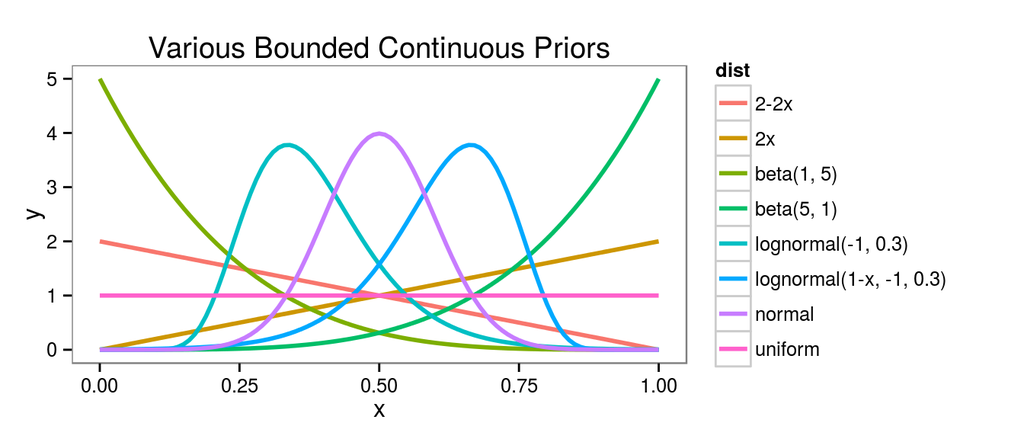

## Real priors from Anthea’s experiments

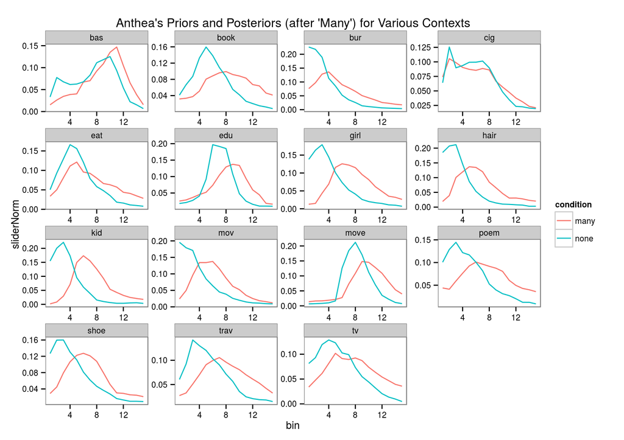

# Simulations

## Code

Here’s a sketch of a scalar adjectives model in WebPPL.

```
var literal_listener = cache(function(utterance, theta) {
Enumerate(function() {
var value = value_prior();
factor(meaning(utterance, theta, value) ? 0 : -Infinity);
return value;
})
})

var speaker = cache(function(value, theta) {
Enumerate(function() {
var utterance = utterance_prior();
var literal_interpretation = literal_listener(utterance, theta);
factor(literal_interpretation.score([], value));
return utterance;
})
})

var listener = function(utterance) {
var value = value_prior();
var theta = theta_prior();
var speaker_choice = speaker(value, theta);
factor(speaker_choice.score([], utterance));
return [value, theta];
}
```

## Results

### On continuous, bounded, “toy” priors

#### Posteriors

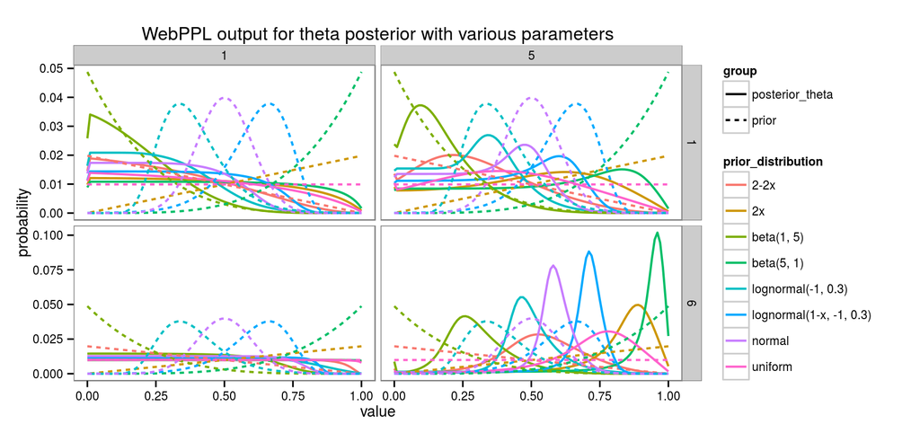

#### Expected inferred thresholds:

```
##        prior_distribution expected percentile
## 1                    2-2x   0.3168    0.53545
## 2                      2x   0.4334    0.18733
## 3              beta(1, 5)   0.1894    0.64930
## 4              beta(5, 1)   0.4648    0.02120
## 5      lognormal(-1, 0.3)   0.2564    0.11084
## 6 lognormal(1-x, -1, 0.3)   0.3519    0.03022
## 7                  normal   0.2942    0.02014
## 8                 uniform   0.4029    0.40594
```

These values are not all the same.

### On Anthea’s elicited priors

- I might want to fit the parameters to the adjective posterior, but first we can try alpha5 cost6.
- Graph model posterior against human posterior.
- Get expected thetas and compare to Anthea’s exptected thetas.

Here’s the output of our lifted variable model compared to Anthea’s data for “many”.

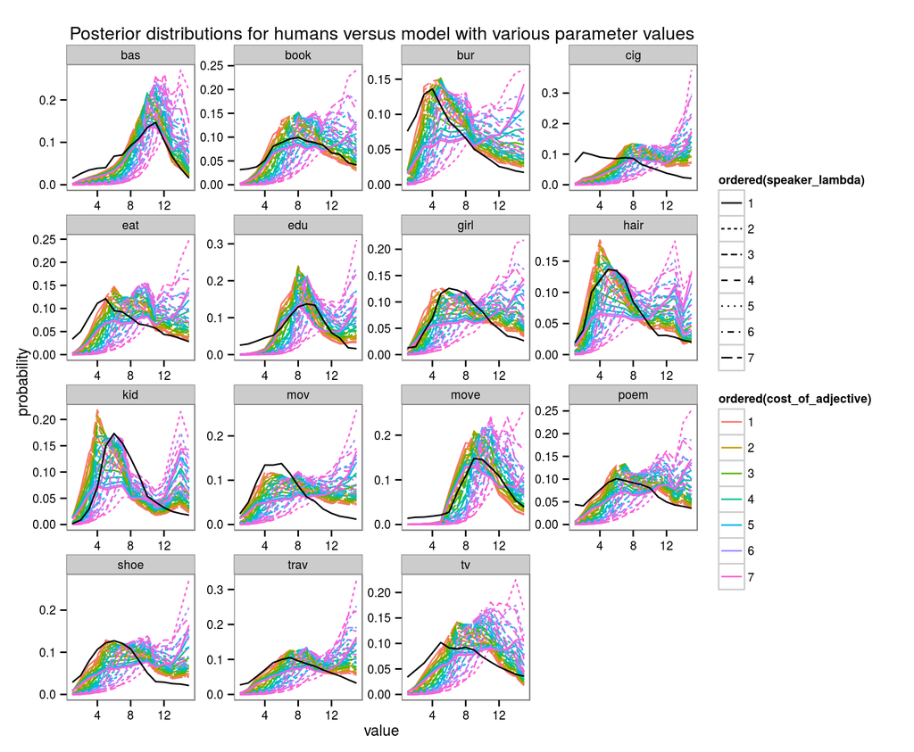

The best fit parameters (i.e. with the lowest average KL divergence) are speaker rationality $\lambda =$ 1 and cost of utterance 1.

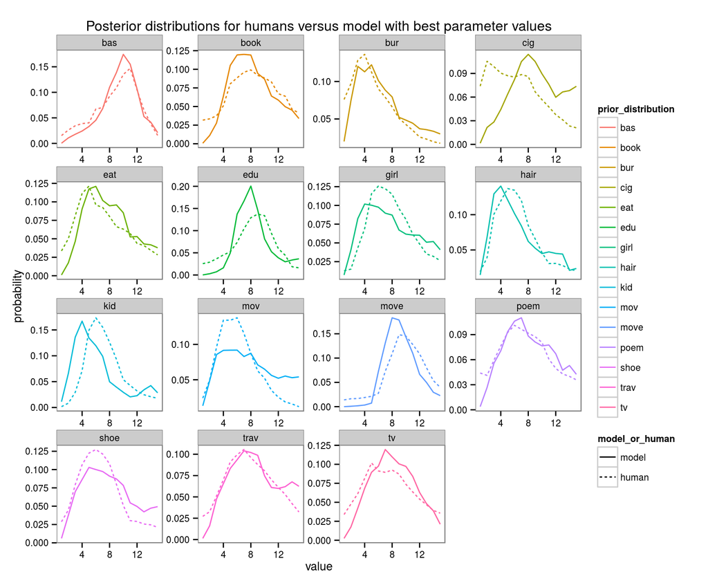

```
##    prior_distribution expected percentile      KL
## 1                 bas    5.833    0.30282 0.04528
## 2                book    5.283    0.48742 0.05968
## 3                 bur    4.404    0.74610 0.05189
## 4                 cig    5.732    0.47233 0.28833
## 5                 eat    5.109    0.59494 0.07124
## 6                 edu    5.278    0.19954 0.17339
## 7                girl    5.012    0.72666 0.07002
## 8                hair    4.340    0.75064 0.04211
## 9                 kid    4.159    0.74996 0.33853
## 10                mov    5.044    0.74964 0.14042
## 11               move    5.647    0.04893 0.14973
## 12               poem    5.270    0.61264 0.04338
## 13               shoe    5.072    0.68827 0.07207
## 14               trav    5.520    0.54500 0.04746
## 15                 tv    5.239    0.54554 0.06066
```

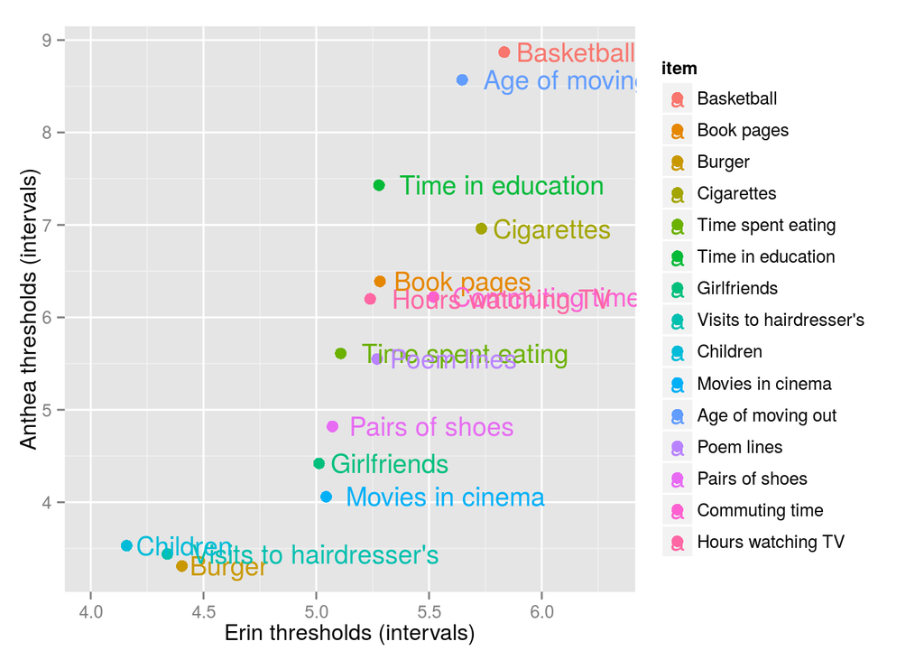

```
##
##  Pearson's product-moment correlation
##
## data:  erin and anthea
## t = 6.964, df = 13, p-value = 9.854e-06
## alternative hypothesis: true correlation is not equal to 0
## 95 percent confidence interval:
##  0.6894 0.9625
## sample estimates:
##   cor
## 0.888
```

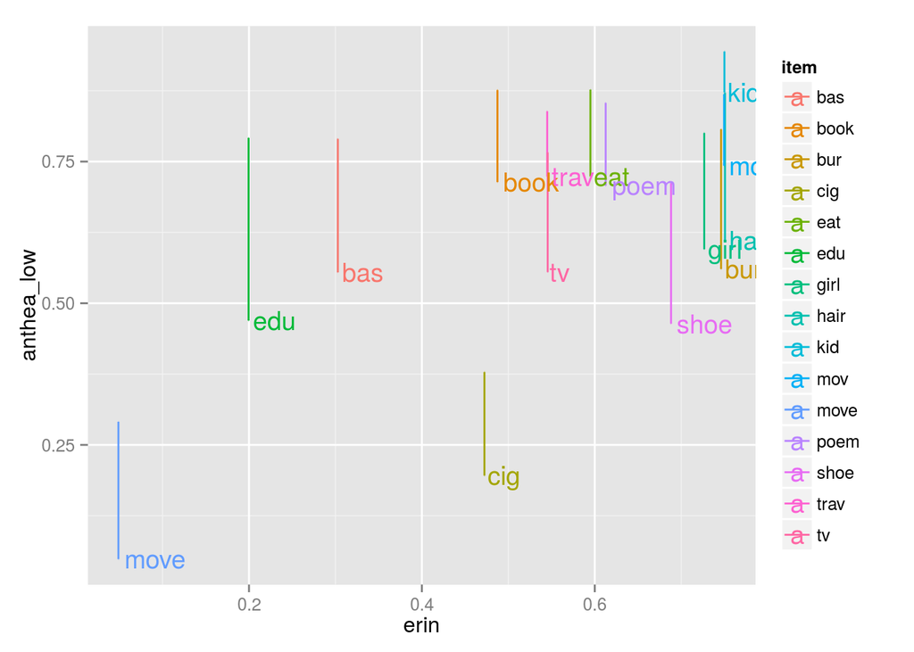

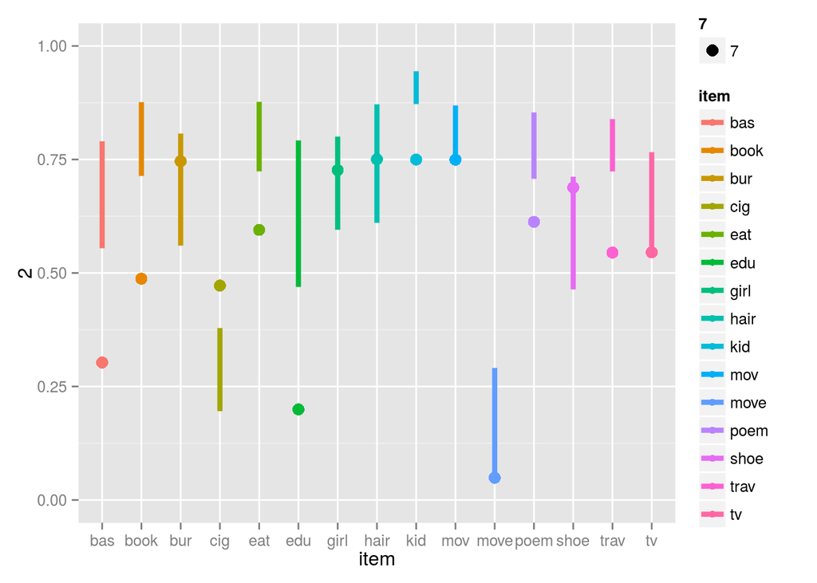